# Sesión 3. Reporte de resultados

Informe de resultados

Nombre

20-04-2022

# El primer paso: la carga

El primero paso SIEMPRE será cargar los paquetes, sin embargo, este paso no es necesario mostrarlo en el reporte, para ello es que configuraremos el ´chunk´para que no se muestre en el reporte “renderizado”, para estoo usaremos el argumento ´include=FALSE´

Haremos lo mismo con la carga de datos

# Revisión general de los datos

Para explorar los datos y las variables a trabajar en el informe, usaremos el paquete ´sjPlot´ para realizar un gráfico de dispersión, usando la función ´view_df´y ´plot_scatter´, podemos incorporar título y cambiar colores, para esto usamos los argumentos de la función.

```r
sjPlot::view_df(datos,
                encoding = "UTF-8")
```

Data frame: datos

| ID | Name | Label | Values | Value Labels |
| --- | --- | --- | --- | --- |
| 1 | id | Identificador de hogar | *range: 1-4549* |  |
| 2 | edad_ent | Edad del entrevistado en años | *range: 20-101* |  |
| 3 | genero_ent |  |  | Masculino Femenino |
| 4 | prevision | Tipo de previsión |  | AFP IPS (ex INP), CANAEMPU, EMPART, SSS CAPREDENA, DIPRECA Otro No está afiliado No responde No sabe |
| 5 | ocup_ent | Situación laboral del entrevistado |  | Desocupado Ocupado |
| 6 | numh | Número de personas en el hogar | *range: 1-6* |  |
| 7 | ytoth | Ingreso total mensual del hogar | *range: 0.0-70931063.8* |  |
| 8 | ahorro | Monto ahorrado | *range: 0-100000000* |  |
| 9 | d_toth | Monto de la deuda total del hogar | *range: 0.0-797052096.0* |  |
| 10 | t_dtoth | Tenencia de deuda total |  | NO SI |
| 11 | factor | Factor de expansión del hogar | *range: 17-8756* |  |
| 12 | deuda_d |  | *range: 0-0* |  |
| 13 | sexo_edad_tramo |  |  | <output omitted> |
| 14 | ing_pc |  | *range: 0.0-21534438.0* |  |

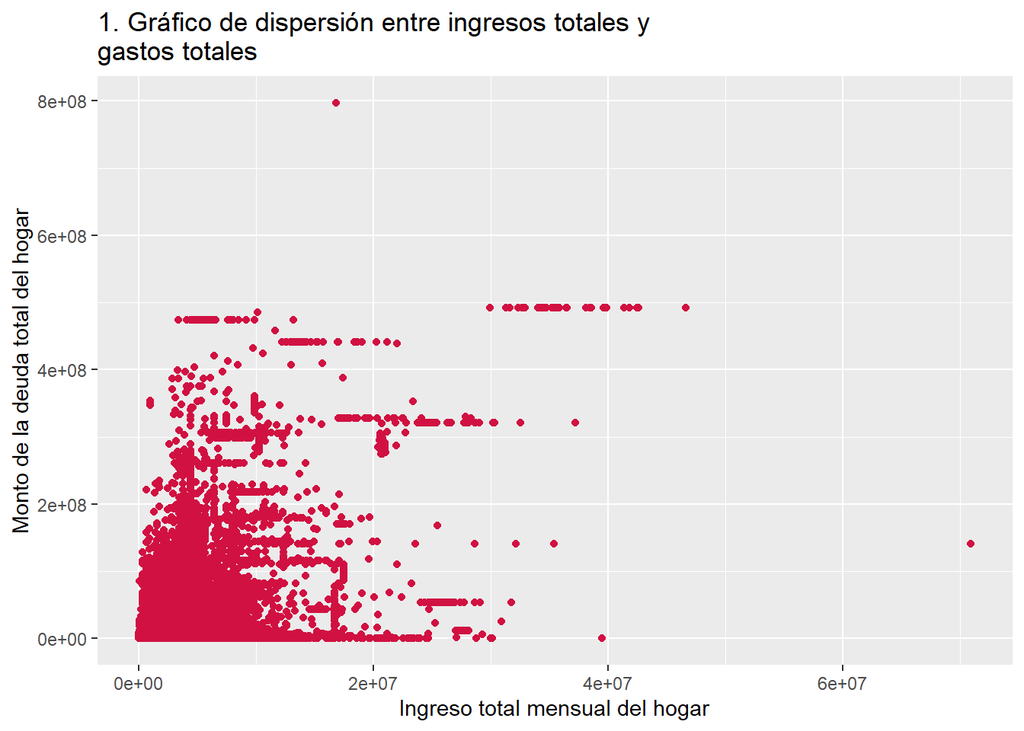

```r
plot_scatter(datos, ytoth, d_toth,
             title = "1. Gráfico de dispersión entre ingresos totales y gastos totales")
```

Como podemos ver, no existe un buena visualización de los datos, lo bueno de trabajar con ´sjPlot´, es que es compatible con el universo ´tidyverse´, por lo que podemos usar el operador pipeline. Entonces filtremos los casos y veamos como queda.

## Gráficos de dispersión

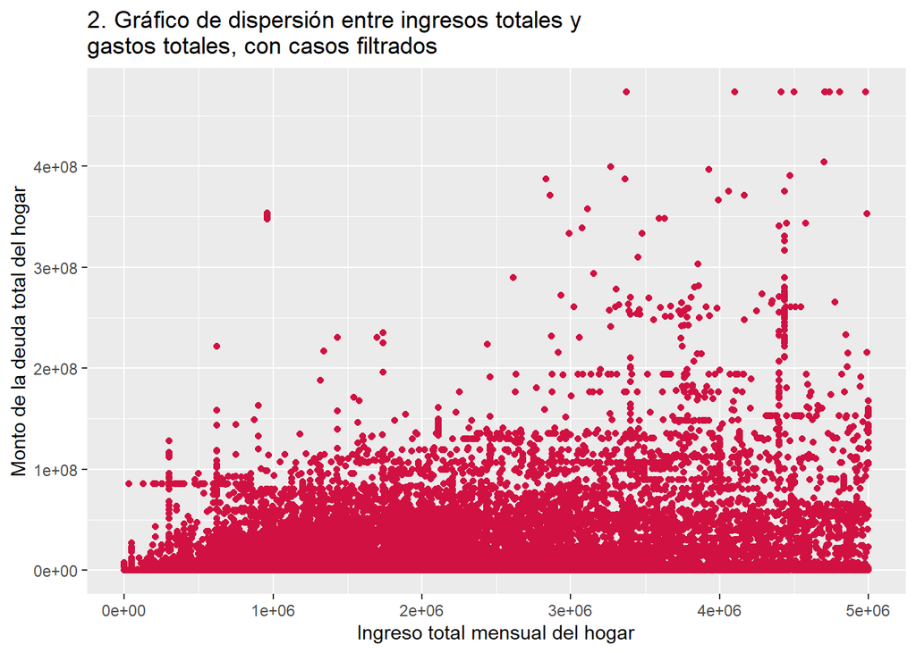

```r
datos %>% filter(ytoth <= 5000000) %>%
  plot_scatter(., ytoth, d_toth,
             title = "2. Gráfico de dispersión entre ingresos totales y gastos totales, con casos filtrados")
```

ya se visualiza mejor, hay muchas configuraciones que puedes explorar, así mismo con el argumento ´fit.grps = “lm”´ puedes incorporar una recta según el método que prefieras, inclusive puedes añadir una categoría de diferenciación, veamos como queda con la variable género

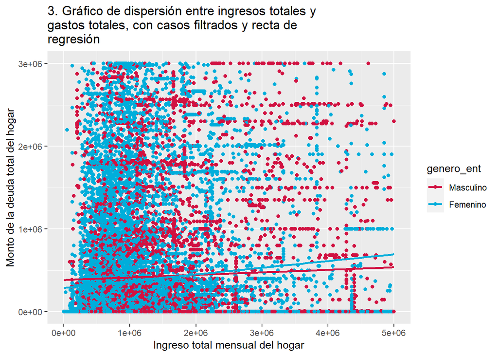

```r
datos %>% filter(ytoth <= 5000000,
                 d_toth <= 3000000) %>%
  plot_scatter(., ytoth, d_toth, genero_ent,
               fit.grps = "lm",
               title = "3. Gráfico de dispersión entre ingresos totales y gastos totales, con casos filtrados y recta de regresión")
```

Nuevamente no hay buena visualización ¡pero nada que no se pueda arreglar!. Para ello usaremos el argumento ´grid´, este nos separará el gráfico de dispersión para hombres y mujeres.

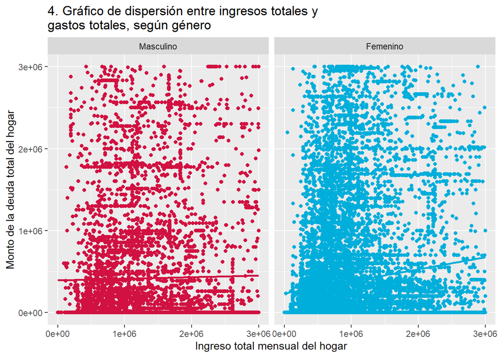

```r
datos %>% filter(ytoth <= 3000000,
                 d_toth <= 3000000) %>%
  plot_scatter(., ytoth, d_toth, genero_ent,
               fit.grps = "lm", grid = TRUE,
               title = "4. Gráfico de dispersión entre ingresos totales y gastos totales, según género")
```

Ahora sólo te queda seguir investigando entre los argumentos de la función ¿qué otras cosas crees que son posibles de graficar?

## Gráfico de barras

Efectivamente, con ´sjPlot´ puedes crear más gráficos todavía. En esta ocasión usaremos la función ´plot_grpfrq´, donde puedes generar barras hasta gráficos de caja, sólo debes explorar en los argumentos.

Ahora generaremos un gráfico de barras para las variables ocupación y género.

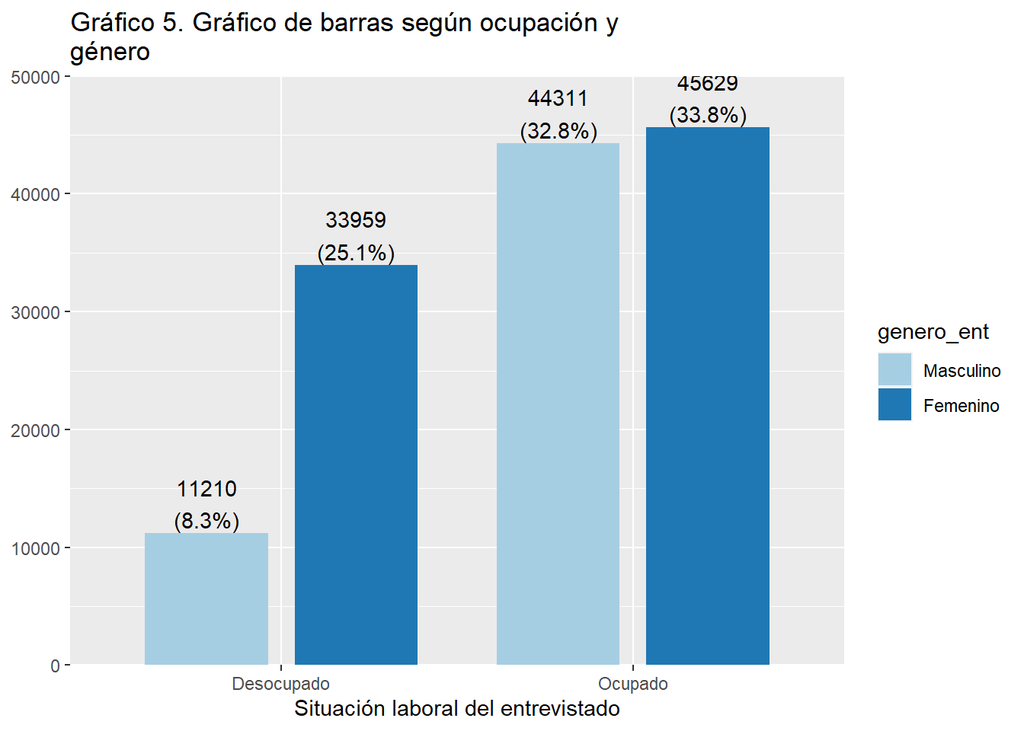

```r
plot_grpfrq(datos$ocup_ent, datos$genero_ent,
            title = "Gráfico 5. Gráfico de barras según ocupación y género",
            type = "bar")
```

# Regresión

Para generar una regresión utilizaremos la función ´lm´del paquete base, para crear un objeto con el nombre modelo0, este almacenará nuestro modelo.

```r
modelo0 <- lm(ytoth ~ 1,
              data = datos,
              weights = factor)
```

```r
sjPlot::tab_model(modelo0,
                  show.ci= F,  # este argumento muestra los intervalos de confianza
                  show.p = T, #Este argumento muestra los valores p
                  show.obs = T, # Este argumento muestra las observaciones
                  title = "Tabla 1. Modelo sin predictores",
                  digits = 2, # muestra la cantidad de dígitos que tednrá la tabla
                  p.style = "numeric_stars")
```

Tabla 1. Modelo sin predictores

Ingreso total mensual del  
hogar

Predictors

Estimates

p

(Intercept)

1633805.15 ***

**<0.001**

Observations

135109

R<sup>2</sup> / R<sup>2</sup> adjusted

0.000 / 0.000

- p<0.05 ** p<0.01 *** p<0.001

```r
modelo1 <- lm(ytoth ~ edad_ent + genero_ent + numh + d_toth + t_dtoth,
              data = datos,
              weights = factor)
```

## Información de modelos

En esta ocasión sólo extraeremos los elementos de los objetos creados, para ello usaremos el símbolo $.

```r
modelo1$coefficients %>%
  kable(caption = "Tabla 3. Coeficientes de los predictores") %>%
  kable_styling(latex_options = c("striped")) %>%
  footnote(general = "Elaboración propia")
```

Tabla 3. Coeficientes de los predictores

|  | x |
| --- | --- |
| (Intercept) | 1.081695e+06 |
| edad_ent | 9.133413e+02 |
| genero_entFemenino | -4.752229e+05 |
| numh | 1.426028e+05 |
| d_toth | 3.138470e-02 |
| t_dtothSI | 5.614811e+03 |

Note:  
Elaboración propia

```r
sjPlot::tab_model(list(modelo0, modelo1), # los modelos estimados
                  show.ci=FALSE, # no mostrar intervalo de confianza (por defecto lo hace)
                  p.style = "stars", # asteriscos de significaciÃ³n estadÃstica
                  dv.labels = c("Modelo 1", "Modelo 2"), # etiquetas de modelos o variables dep.
                  string.pred = "Predictores",
                  encoding =  "UTF-8")
```

Modelo 1

Modelo 2

Predictores

Estimates

Estimates

(Intercept)

1633805.15 ***

1081694.83 ***

913.34 **

genero_ent: Femenino

-475222.86 ***

142602.84 ***

Monto de la deuda total  
del hogar

0.03 ***

Tenencia de deuda total:  
SI

5614.81

Observations

135109

135109

R<sup>2</sup> / R<sup>2</sup> adjusted

0.000 / 0.000

0.275 / 0.275

- p<0.05 ** p<0.01 *** p<0.001

## Gráficar los modelos

Nuevamente para la visualización utilizaremos ´sjPlot´, con la función ´plot_model´ gradicaremos el modelo creado.

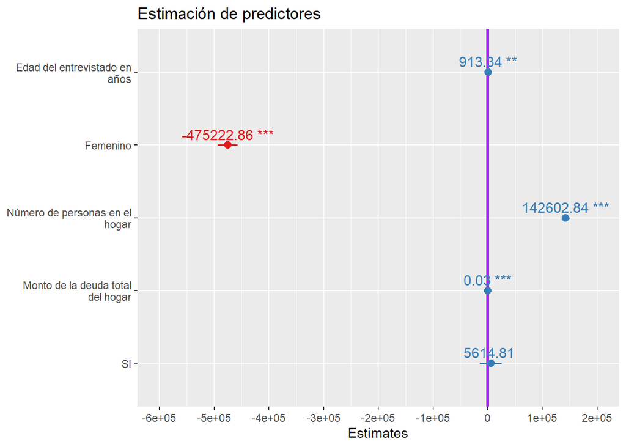

```r
sjPlot::plot_model(modelo1,
                   show.p = T,
                   show.values =  T,
                   ci.lvl = c(0.95),
                   title = "Estimación de predictores",
                   vline.color = "purple")
```